# Lab Report #1 Solutions

DATA101: Introduction to Data Science

**In this lab report, you are to analyse the “Bike Sharing” dataset available under the “Datasets” section of the DATA101 Blackboard page. The aim of the report is to provide insight into the use of the bike sharing service in London. Your lab report should include:**

1. **an appropriate measure of centrality and measure of dispersion for hourly bike hires over 2015-2016. This should include a relevant graphical display.**

   **Solution:**

   Although both a histogram and boxplot are appropriate graphical displays, a histogram more easily shows skewness/asymmetry.

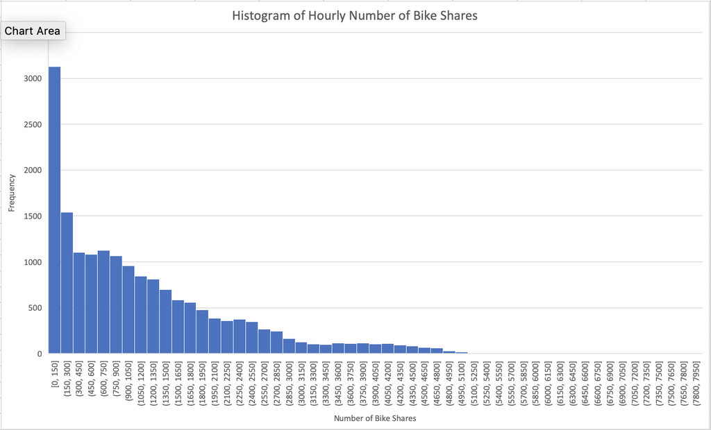

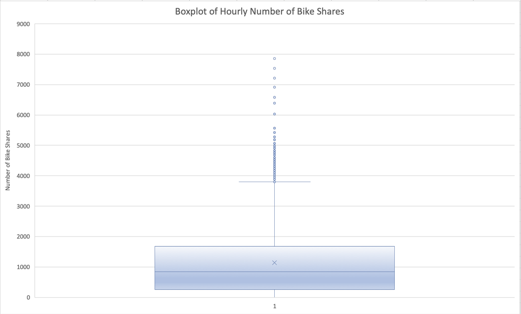

   Both the histogram and boxplot indicate a massive range to the data from roughly 0 to just under 8,000 hourly bike shares (which can be confirmed from summary statistics) and show clear skewness/asymmetry in the distribution of hourly bike shares. Based on skewness/asymmetry in the distribution of hourly bike shares, we will prefer to report the median as a measure of centrality and interquartile range as a measure of dispersion. As shown in summary output, the median is 846 hourly bike shares, and the intequartile range is 1,416 hourly bike shares.

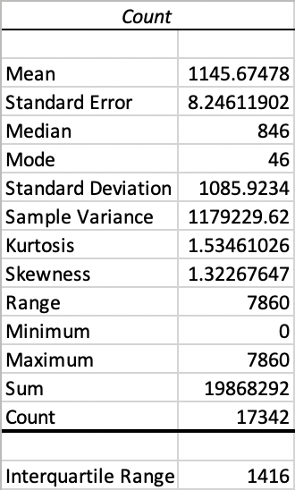

2. **a question that would be of interest to Transport for London in terms of bike use and that relates to a difference. Answer this question in words and with a supporting graphical display. This should also include relevant numeric measures/table(s) related to the difference.**

   **Solution:**

   There are a number of possible questions of interest for Transport for London in terms of bike use and that relate to a difference. Three of these include:
   - Do hourly bike shares change based on season?

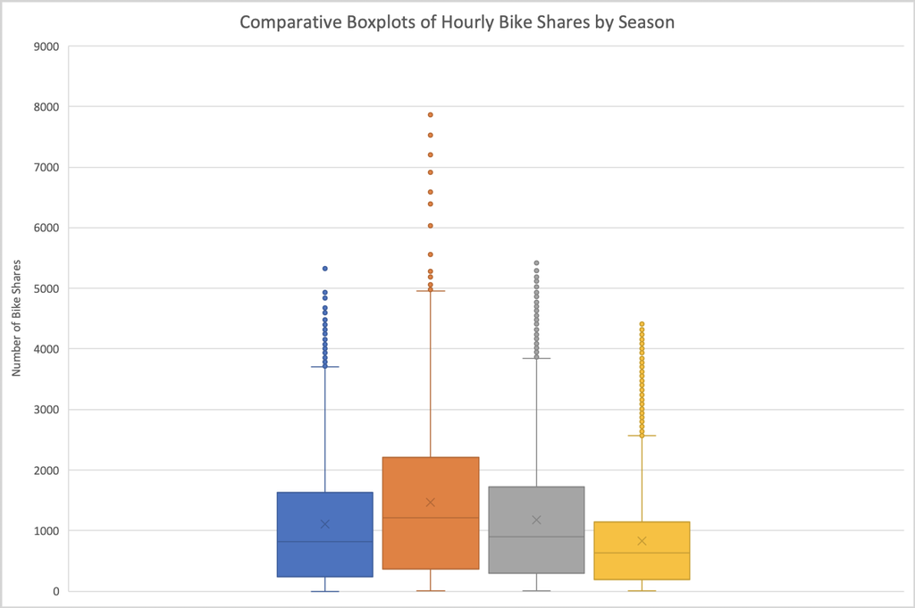

     Hourly bike shares appear to increase slightly from spring (blue) to summer (orange), then decrease in the autumn (grey) to similar levels observed in spring, and then further decrease in winter (yellow). It is not clear from the boxplots whether this seasonal change is in fact a real/statistically significant change or not, as there is a lot of overlap in the boxplots. Examining average hourly bike shares by season, we see a similar trend in the means. In spring, the average bike shares per hour is approximately 1,104. This increases to approximately 1,464 bike shares per hour in the summer, then decreases to roughly 1,179 bike shares per hour in the autumn (so nearly the same as for spring), and is at its lowest in winter with approximately 827 bike shares per hour.

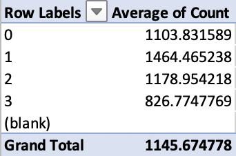

     **Comment on difference/trend:**

     This trend seems reasonable. As the weather gets warmer, we would expect people to be more likely to use a bicycle as a means of transportation. Additionally, warmer months tend to be more popular months for tourism, so we would expect the most tourists in summer, followed by spring and autumn. With more tourists in the city, it would be natural to see bike shares increase as tourists make use of bikes to explore the city.

     **Data manipulation:**

     In order to produce the comparative boxplots, we had to separately filter according to each season and copy counts of bike shares to a separate column in a new speadsheet (so four columns in total). Averages by season required the use of a pivot table.
   - Do hourly bike shares differ for weekdays and weekends?

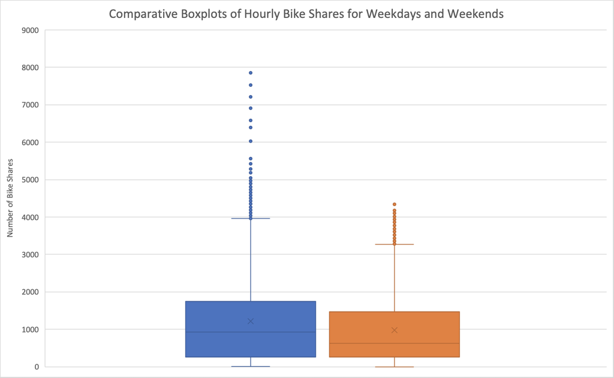

     Hourly bike shares appear to be slightly higher for weekdays (blue) than weekends (orange). It is not clear from the boxplots whether this is a real/statistically significant difference or not, as there is a lot of overlap in the boxplots. Examining average hourly bike shares for weekdays and weekends, we see a similar trend in the means. For weekdays, the average bike shares per hour is approximately 1,211. This decreases to approximately 981 bike shares per hour on the weekend.

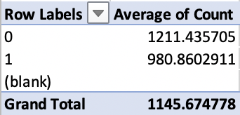

     **Comment on difference/trend:**

     This trend may be related to numbers of people in London on weekdays vs. weekends. Many people living in the suburbs will come into the city for work on weekdays, and a number of these people may make use of bikes to get around the city during work hours.

     **Data manipulation:**

     In order to produce the comparative boxplots, we had to separately filter according to weekdays (0) and weekends (1) and copy counts of bike shares to a separate column in a new speadsheet (so two columns in total). Averages by weekend and weekday required the use of a pivot table.
   - Do hourly bike shares differ for holidays and non-holidays?

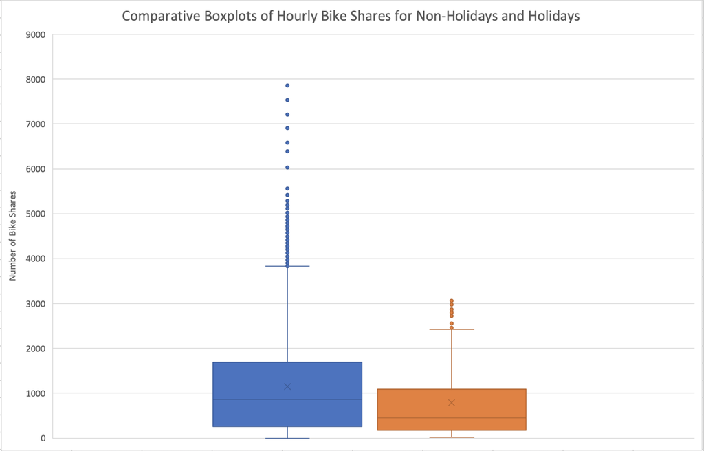

     Hourly bike shares appear to drop on public holidays (orange) as compared to non-holidays (blue). It is not clear from the boxplots whether this is a real/statistically significant difference or not, as there is a lot of overlap in the boxplots. Examining average hourly bike shares for holidays and non-holidays, we see a similar trend in the means. For non-holidays, the average bike shares per hour is approximately 1,153. This decreases to approximately 788 bike shares per hour for public holidays

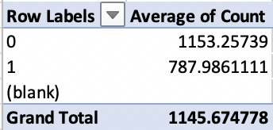

     **Comment on difference/trend:**

     This trend may again be related to numbers of people in London on non-holidays vs. public holidays Many people may leave the city for public holidays. Additionally, people may prefer to spend time with family and/or friends on holidays and be less likely to be out and about in the city. This would explain why bike shares drop during holidays.

     **Data manipulation:**

     In order to produce the comparative boxplots, we had to separately filter according to non-holidays (0) and holidays (1) and copy counts of bike shares to a separate column in a new speadsheet (so two columns in total). Averages by holidays and non-holidays required the use of a pivot table.
3. **a linear regression that can be used to predict number of bike shares/hires based only on the “feels like” temperature, humidity, and wind speed. Relevant linear regression output should be included, and you should provide**

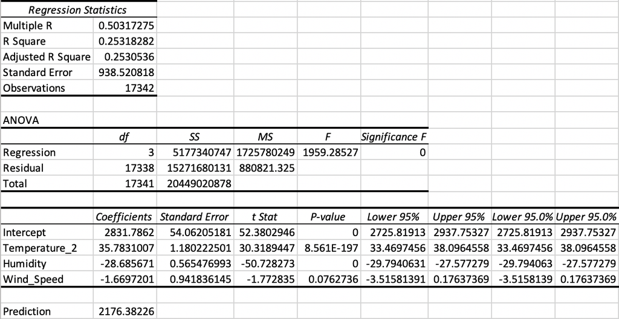

   - **a brief (but specific) explanation of what the linear regression output tells you about the model and the significance of individual independent variables.**
     - From the ANOVA table, the *p*-value of approximately 0 provides strong evidence that the “feels like” temperature, humidity, and wind speed as a whole/group are useful in predicting the number of bike shares.
     - Based on the value of adjusted $R^{2}$, we can say that approximately 25% of the variability in the number of bike shares can be explained by the relationship between number of bike shares and the “feels like” temperature, humidity, and wind speed.
     - The *p*-values for the “feels like” temperature and humidity variables are approximately 0 (and well below 0.05), suggesting that both of these are useful in predicting the number of bike shares. Wind speed is not statistically significant after adjusting/accounting for “feels like” temperature and humidity (*p*-value of approximately 0.076).
   - **a prediction of bike hires when the “feels like” temperature is 22°C, the humidity is 50%, and the wind speed is 5 km/h.**
     - The estimated linear regression equation is of the form
       $$\mbox{Count} = 2{,}831.786 + 35.783 \times \mbox{Temperature_2} - 28.686 \times \mbox{Humidity} - 1.670 \times \mbox{Wind_Speed}$$
       .
     - For a “feels like” temperature of 22°C, humidity of 50%, and wind speed of 5 km/h,
       $$\mbox{Count} = 2{,}831.786 + 35.783 \times 22 - 28.686 \times 50 - 1.670 \times 5 = 2{,}176.382,$$
       so we would predict approximately 2,176 bike shares.